# A1 programming

```python
import matplotlib.pyplot as plt
import numpy as np
import _pickle as pickle
```

# Q2

First load the datas from each dataset, I named them based on dataset number and category(small training, large training, test)

```python
with open("C:/Users/yanga/Desktop/UT/CSCC11/A1_Dataset/datasets_3/small_train.pkl", "rb") as s3:
    small3=pickle.load(s3)

ys3 = small3["Y"]
xs3 = small3["X"]

with open("C:/Users/yanga/Desktop/UT/CSCC11/A1_Dataset/datasets_3/large_train.pkl", "rb") as b3:
    big3=pickle.load(b3)

yb3 = big3["Y"]
xb3 = big3["X"]

with open("C:/Users/yanga/Desktop/UT/CSCC11/A1_Dataset/datasets_3/test.pkl", "rb") as t3:
    test3=pickle.load(t3)

y_test3 = test3["Y"]
x_test3 = test3["X"]

with open("C:/Users/yanga/Desktop/UT/CSCC11/A1_Dataset/datasets_2/small_train.pkl", "rb") as s2:
    small2=pickle.load(s2)

ys2 = small2["Y"]
xs2 = small2["X"]

with open("C:/Users/yanga/Desktop/UT/CSCC11/A1_Dataset/datasets_2/large_train.pkl", "rb") as b2:
    big2=pickle.load(b2)

yb2 = big2["Y"]
xb2 = big2["X"]

with open("C:/Users/yanga/Desktop/UT/CSCC11/A1_Dataset/datasets_2/test.pkl", "rb") as t2:
    test2=pickle.load(t2)

y_test2 = test2["Y"]
x_test2 = test2["X"]

with open("C:/Users/yanga/Desktop/UT/CSCC11/A1_Dataset/datasets_1/small_train.pkl", "rb") as s1:
    small1=pickle.load(s1)

ys1 = small1["Y"]
xs1 = small1["X"]

with open("C:/Users/yanga/Desktop/UT/CSCC11/A1_Dataset/datasets_1/large_train.pkl", "rb") as b1:
    big1=pickle.load(b1)

yb1 = big1["Y"]
xb1 = big1["X"]

with open("C:/Users/yanga/Desktop/UT/CSCC11/A1_Dataset/datasets_1/test.pkl", "rb") as t1:
    test1=pickle.load(t1)

y_test1 = test1["Y"]
x_test1 = test1["X"]
```

The estimation of $\mathbf{w}$ is:

$\mathbf{w} = (X^TX)^-1X^TY$

```python
def find_parameters(x, y, k):
    '''
    x:array    y:array   k:int
    A function designed to find the paramters of scalar to scalar regression, k is the largest monomial degree
    '''
    x = x.reshape(np.shape(x)[0],)                 #adjustment for data x
    vander = np.vander(x, k+1, increasing = "T")   # construct matrix for x
    p1 = np.linalg.inv(vander.T@vander)            #calculate （X.T X)^-1
    y = y.reshape(np.shape(y)[0],)                 #adjustment for data y
    p2 = vander.T@y                                #calculate (X.T Y)
    w = p1@p2                                      #parameter w is estimated by (X.T X)^-1(X.T Y)
    return w
```

The training error is the error between desired output and a predicted output calculated by using the same data that trained the model:

$\large E_{training} = \frac{1}{N_{training}} \sum_{p=1}^{N_{training}}E^P$

and $E^P$ is:

$\large E^P = \frac{1}{2} \sum_{o =1}^{N_o}(d_o^p - y_o^p)^2$

since $N_o = 1$, therefore $E^P$ is:

$\large E_{training} = \frac{1}{N_{training}} \sum_{p=1}^{N_{training}} \frac{1}{2}(d^p - y^p)^2$

The test error is the error between desired output and predicted output calculated by the model trained with the training dataset: $\large E_{test} = \frac{1}{N_{test}} \sum_{p=1}^{N_{test}} \frac{1}{2}(d^p - y^p)^2$

```python
def train_error(x, y):
    '''
    x:array   y:array
    give a set of inputs and outputs, calculate training error of each degree of model
    '''
    train_error = np.zeros(11)                              #set up the train error container
    n = np.shape(y)[0]                                      #get the size of data
    for k in range(1,11):
        w = find_parameters(x, y, k)                        #calculate model of each degree
        x = x.reshape(np.shape(x)[0],)                      #adjust input for calculation
        vander = np.vander(x, k+1, increasing = "T")        #calculate corresponding degree of x matrix
        yp = vander@w                                       #calculate predicted output
        yd = y.reshape(np.shape(y)[0],)                     #adjust actual output for calculatioin
        train_error[k] = (1/n)*sum((1/2)*(yd - yp)**2)      #calculate the training error
    return np.log(train_error[1:])                              #return the log-training error



def test_error(xtrain, ytrain, xt, yt):
    '''
    xtrain, ytrain, xt, yt: array
    calculate the test error of each degree of model
    '''
    test_error = np.zeros(11)                               #set up the test error container
    n = np.shape(yt)[0]                                     #get the size of test data
    for k in range(1,11):
        w = find_parameters(xtrain, ytrain, k)              #calculate model based on training set
        xt = xt.reshape(np.shape(xt)[0],)                   #adjust test input for calculation
        vander = np.vander(xt, k+1, increasing = "T")       #calculate corresponding degree of x matrix
        yp = vander@w                                       #calculate predicted output
        yd = yt.reshape(np.shape(yt)[0],)                   #adjust test output for calculation
        test_error[k] = (1/n)*sum((1/2)*(yd - yp)**2)       #calculate test error
    return np.log(test_error[1:])                               #return the log-test error



def visualize_error(error1, error2, k, name1, name2):
    '''
    error1, error2: array
    k, name1, name2:string
    plot the error by complexity of the model
    '''
    plt.plot(range(1,11), error1, 'bo-', label = name1)
    plt.plot(range(1,11), error2, 'ro-', label = name2)
    plt.xlabel("model degree")
    plt.ylabel("log error")
    plt.title(k)
    plt.legend()
    plt.show()
```

Calculate training and test errors based on small training size from dataset 3:

```python
train_error_3small = train_error(xs3,ys3)
test_error_3small = test_error(xs3, ys3, x_test3, y_test3)
```

Calculate training and test errors based on large training size from dataset 3:

```python
train_error_3big = train_error(xb3,yb3)
test_error_3big = test_error(xb3, yb3, x_test3, y_test3)
```

Calculate training and test errors based on small training size from dataset 2:

```python
train_error_2small = train_error(xs2,ys2)
test_error_2small = test_error(xs2, ys2, x_test2, y_test2)
```

Calculate training and test errors based on large training size from dataset 2:

```python
train_error_2big = train_error(xb2,yb2)
test_error_2big = test_error(xb2, yb2, x_test2, y_test2)
```

Calculate training and test errors based on small training size from dataset 1:

```python
train_error_1small = train_error(xs1,ys1)
test_error_1small = test_error(xs1, ys1, x_test1, y_test1)
```

Calculate training and test errors based on large training size from dataset 1:

```python
train_error_1big = train_error(xb1,yb1)
test_error_1big = test_error(xb1, yb1, x_test1, y_test1)
```

Graph training errors of small and large training size from various datasets:

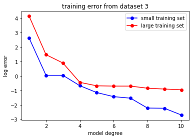

```python
 visualize_error(train_error_3small, train_error_3big, "training error from dataset 3", "small training set", "large training set")
```

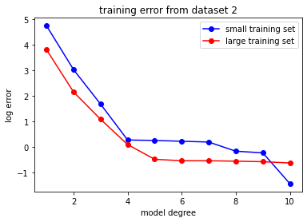

```python
 visualize_error(train_error_2small, train_error_2big, "training error from dataset 2", "small training set", "large training set")
```

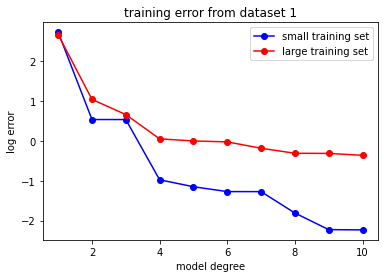

```python
 visualize_error(train_error_1small, train_error_1big, "training error from dataset 1", "small training set", "large training set")
```

Graph test errors of small and large training size from various datasets:

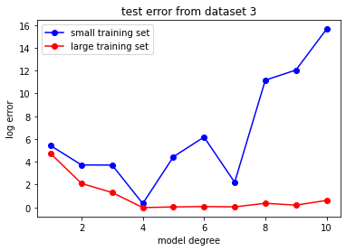

```python
visualize_error(test_error_3small, test_error_3big, "test error from dataset 3", "small training set", "large training set")
```

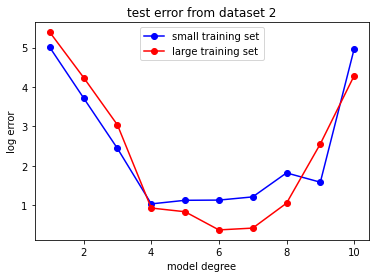

```python
visualize_error(test_error_2small, test_error_2big, "test error from dataset 2", "small training set", "large training set")
```

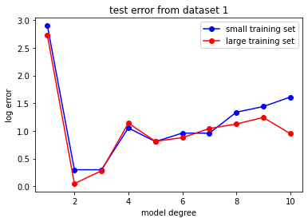

```python
visualize_error(test_error_1small, test_error_1big, "test error from dataset 1", "small training set", "large training set")
```

Since the size of test set are all the same, in order to observe the effect of increasing size of test set, I plan to use the large sample set as test set, which is training the model with small sample data and use the model to predict large sample outputs

Calculate test errors of different data set, holding training set size constant:

```python
test_error_3_sl = test_error(xs3, ys3, xb3, yb3)
test_error_2_sl = test_error(xs2, ys2, xb2, yb2)
test_error_1_sl = test_error(xs1, ys1, xb1, yb1)
```

Graph the effect of increasing test size using real test set and large training set as a size increased test set:

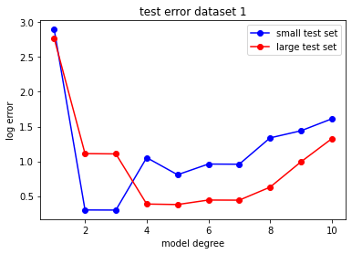

```python
visualize_error(test_error_1small, test_error_1_sl, "test error dataset 1", "small test set", "large test set")
```

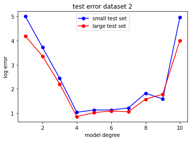

```python
visualize_error(test_error_2small, test_error_2_sl, "test error dataset 2", "small test set", "large test set")
```

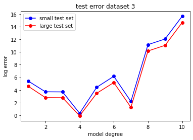

```python
visualize_error(test_error_3small, test_error_3_sl, "test error dataset 3", "small test set", "large test set")
```

*Q3 Answer* In order to obtain a good model, larger training set is better, since test error is smaller compares to a smaller training set.

Graph training and test error to compare the effect of complexity:

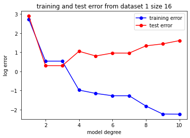

```python
visualize_error(train_error_1small, test_error_1small, "training and test error from dataset 1 size 16", "training error", "test error")
```

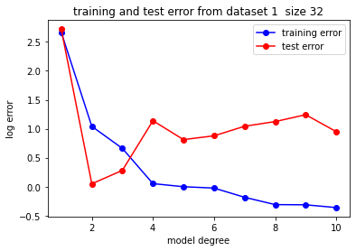

```python
visualize_error(train_error_1big, test_error_1big, "training and test error from dataset 1  size 32", "training error", "test error")
```

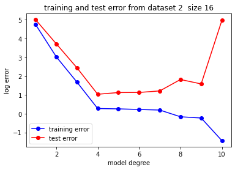

```python
visualize_error(train_error_2small, test_error_2small, "training and test error from dataset 2  size 16", "training error", "test error")
```

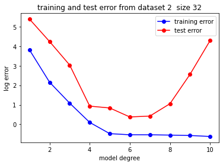

```python
visualize_error(train_error_2big, test_error_2big, "training and test error from dataset 2  size 32", "training error", "test error")
```

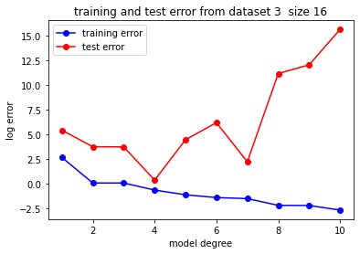

```python
visualize_error(train_error_3small, test_error_3small, "training and test error from dataset 3  size 16", "training error", "test error")
```

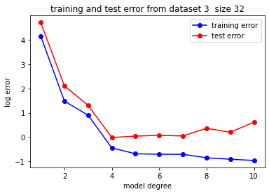

```python
visualize_error(train_error_3big, test_error_3big, "training and test error from dataset 3  size 32", "training error", "test error")
```

*Q4&5 Answer* Training and test error are high for a too simple model, but as the complexity increases, training error continues to decrease, but test error will decrease at first then increase as the model becomes too complex

A way of calculating cross validation with a dataset is:

$\large CV = \frac{1}{N} \sum_{i=1}^{N}(\frac{y_i - \hat{y}_i}{1 - h_i})^2$

where $\hat{y}$ is equal to $Hy$, and $h_i$ is the ith diagonal entry of matrix $H = X(X^TX)^{-1}X^T$

```python
def find_H(x, k):
    '''
    x:array  k:int
    A function for finding H in order to calculate the cross validation score
    '''
    x = x.reshape(np.shape(x)[0],)
    vander = np.vander(x, k+1, increasing = "T")
    inv = np.linalg.inv(vander.T@vander)
    p1 = np.matmul(vander, inv)
    h = p1@vander.T
    return h




def cv(y, h):
    '''
    y,h: array
    Calculate the cross validation value based on the formula of CV
    '''
    cv = 0
    yp = h@y
    n = np.shape(y)[0]
    for i in range(n):
        cv += ((y[i] - yp[i])/(1 - h[i,i]))**2
    return (1/n)*cv

def compare_cv(y, x):
    '''
    y,x:array
    returns a list of cv for degree 1 to 10 model
    '''
    cross_valid = np.zeros((11, 2))
    for i in range(1,11):
        h = find_H(x, i)
        cross_valid[i,0] = i
        cross_valid[i,1] = cv(y, h)
    return cross_valid
```

Sub in test set to estimate which degree of model generated the data:

```python
cv_list1 = compare_cv(y_test1,x_test1)
print(cv_list1[1:])
```

```
[[1.000000 29.603939]
 [2.000000 1.139224]
 [3.000000 2.047130]
 [4.000000 9.153320]
 [5.000000 24.109560]
 [6.000000 15.098556]
 [7.000000 2305.992590]
 [8.000000 115387.652806]
 [9.000000 227816.485228]
 [10.000000 244954354.479101]]
```

```python
cv_list2 = compare_cv(y_test2,x_test2)
print(cv_list2[1:])
```

```
[[1.000000 387.179155]
 [2.000000 149.986670]
 [3.000000 86.353165]
 [4.000000 8.776879]
 [5.000000 15.769561]
 [6.000000 116.437263]
 [7.000000 5243.007969]
 [8.000000 62846.661278]
 [9.000000 2136912.179890]
 [10.000000 58966582.653078]]
```

```python
cv_list3 = compare_cv(y_test3,x_test3)
print(cv_list3[1:])
```

```
[[1.000000 258.086183]
 [2.000000 19.723507]
 [3.000000 19.940355]
 [4.000000 2.737786]
 [5.000000 5.361278]
 [6.000000 32.741082]
 [7.000000 11.332848]
 [8.000000 271.358263]
 [9.000000 97.966612]
 [10.000000 42647.162283]]
```

*Q7 Answer* By comparing the cv values of each dataset, degree 2 model was used to generate data set 1, degree 4 model was used to generate data set 2 and 3